# NextWordPredictorApp

3 September 2017

## About - The Project and The App

This project was taken up as part of course 10 of the Data Science Specialization on Coursera.

The App "Next Word Predictor" takes a word or phrase as input from the user and tries to guess the next word that might follow the input phrase meaningfully.

The app has been deployed on the Shinyapps.io server hosted by RStudio thus making it available for anyone and everyone to try it out.

Shiny App Link : https://sapnagiri.shinyapps.io/nextwordpredictor/

## Algorithm

- To develop this app a corpus of text was required which could be used for training the algorithm to predict next word.
- Link to training data : https://d396qusza40orc.cloudfront.net/dsscapstone/dataset/Coursera-SwiftKey.zip
- The entire data in US_EN folder has been used.
- The training data was first cleaned and filtered to remove any special characters, completely transferred to lower case and converted into n-grams where n=1,2,3 and 4.
- The n-grams were converted into a dataframe containg the n-gram and the count of the n-gram in the entire text corpus.
- Each type of n-gram dataframe was stored in a separate RData file to be used by the prediction function to predict the next word.

## Working of the App

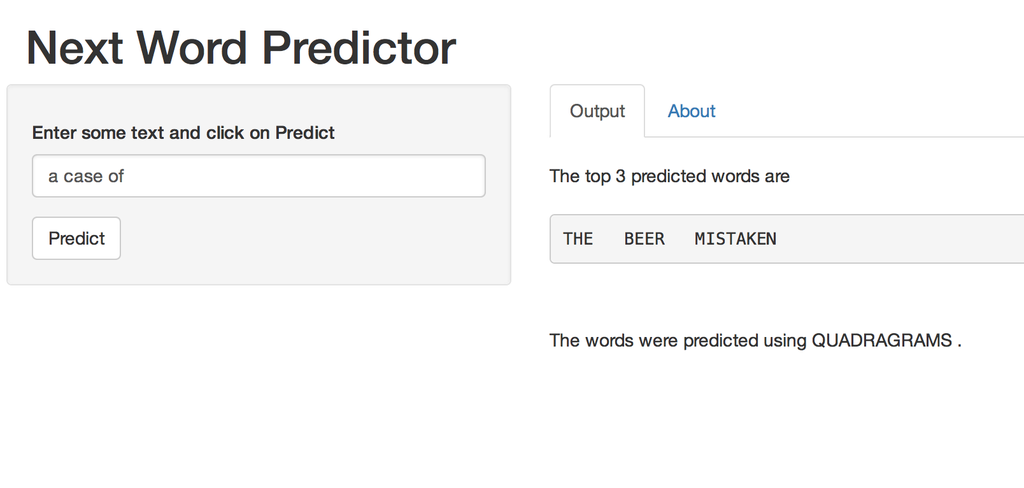

## Working of the App (contd…)

1. Launch the app.
2. Enter some text in the textbox and click on 'Predict'.
3. The app will display a list of top 3 words suitable as the next word for the phrase.
4. If no text is entered on clicking of Predict, then a message "Please enter some text" is displayed.
5. If no prediction possible, then the top 3 words in the corpus are displayed randomly.